# Session 1

Note: This document is written using Rmarkdown. You can produce HTML and Pdf documents using Rmarkdown and Rstudio. Think documentation, reports, ppt.

## Getting started instructions

- Please install RStudio and R, if you dont have it. [Here](https://www.rstudio.com/products/rstudio/download/)
- Go on Github. Fork my repo and clone that in your computer.
- The dataset we will work on today is a fun dataset. IMDB Movies. Please go ahead and download the data folder in your project directory. [Download from here](https://drive.google.com/open?id=0B9NCHJOuElCGfllXSFJsd2dFWVdabEdjQVJHSmpKaUVfZUw3VTM1NFMyT0Z6dlIzSVM1MGM)
- Install all the packages

```r
# list.of.packages <- c("devtools","readr", "read_xl", "ggplot2", "dplyr", "data.table","rmarkdown", "stringr")
# new.packages <- list.of.packages[!(list.of.packages %in% installed.packages()[,"Package"])]
# if(length(new.packages)) install.packages(new.packages)
```

### How to get help when after downloading a package?

- Vignette
- Github

## Read the data

Note: - Common formats I know about in Biology - Flat files - tsv, csv, txt, *some random extension of a tab delimited file*, xlsx/xls

- You don’t have Databases SQL, JSON etc..

### Two recommended packages

1. [`readr`](https://github.com/hadley/readr) and [`readxl`](https://github.com/hadley/readxl) for readability and concise
2. [`data.table::fread`](https://github.com/Rdatatable/data.table) for performance and consistency

```r
library(readr)
library(data.table)
titles_df = read_csv("data/titles.csv")
cast_df = fread("data/cast.csv", sep = ",",header = T, verbose = T, stringsAsFactors = F)
```

[output not shown]

```r
rel_dates_df <- read_csv("data/release_dates.csv")
```

That was easy right!

- Please note the `<-` and `=` assignments. Lets talk! But in practical use cases choose either.
- `<<-` parent scope and `<-` local scope. *what is scope?*

```r
str(rel_dates_df)
```

```
## Classes 'tbl_df', 'tbl' and 'data.frame':    410090 obs. of  4 variables:
##  $ title  : chr  "#73, Shaanthi Nivaasa" "#AnonOccupy: Bio of a Villain" "#Beings" "#Ewankosau saranghaeyo" ...
##  $ year   : int  2007 2015 2015 2015 2014 2014 2014 2014 2015 1971 ...
##  $ country: chr  "India" "USA" "Romania" "Philippines" ...
##  $ date   : Date, format: "2007-06-15" "2015-11-05" ...
```

This is the structure command to look at meta deta for your data. We need to understand common data types in R

- Atomic Vectors
- Boolean/Logical #R is case sensitive T, F, TRUE, FALSE
- Numeric #double
- Integer #integer
- Character
- Complex! # 2+ 1i
- Matrices and array #I personally did not use them so much
- Lists (trivial and common data strucure)
- Factors
- levels()
- Dataframe

### Q. How to know what class is the variable.

```r
class(rel_dates_df)
```

```
## [1] "tbl_df"     "tbl"        "data.frame"
```

```r
class(rel_dates_df$title)
```

```
## [1] "character"
```

### What are some basic functions to check my variables, structure, dimensions, peek into my data?

```r
str(rel_dates_df)
```

```
## Classes 'tbl_df', 'tbl' and 'data.frame':    410090 obs. of  4 variables:
##  $ title  : chr  "#73, Shaanthi Nivaasa" "#AnonOccupy: Bio of a Villain" "#Beings" "#Ewankosau saranghaeyo" ...
##  $ year   : int  2007 2015 2015 2015 2014 2014 2014 2014 2015 1971 ...
##  $ country: chr  "India" "USA" "Romania" "Philippines" ...
##  $ date   : Date, format: "2007-06-15" "2015-11-05" ...
```

```r
dim(cast_df)
```

```
## [1] 3330006       6
```

```r
nrow(titles_df)
```

```
## [1] 215867
```

```r
ncol(rel_dates_df)
```

```
## [1] 4
```

```r
names(cast_df)
```

```
## [1] "title"     "year"      "name"      "type"      "character" "n"
```

```r
head(cast_df)
```

```
##                                title year      name  type character  n
## 1:                   Suuri illusioni 1985    Homo $ actor    Guests 22
## 2:    Gangsta Rap: The Glockumentary 2007 Too $hort actor   Himself NA
## 3:                 Menace II Society 1993 Too $hort actor   Lew-Loc 27
## 4: Porndogs: The Adventures of Sadie 2009 Too $hort actor     Bosco  3
## 5:                Stop Pepper Palmer 2014 Too $hort actor   Himself NA
## 6:                           Townbiz 2010 Too $hort actor   Himself NA
```

```r
tail(cast_df)
```

```
##                               title year                        name
## 1: Niceland (Population. 1.000.002) 2004     Steinunn ?orvaldsd?ttir
## 2:                   Stuttur Frakki 1993   Sveinbj?rg ??rhallsd?ttir
## 3:                          Foxtrot 1988           Lilja ??risd?ttir
## 4: Niceland (Population. 1.000.002) 2004   Sigr??ur J?na ??risd?ttir
## 5:                     U.S.S.S.S... 2003 Krist?n Andrea ??r?ard?ttir
## 6:                Bye Bye Blue Bird 1999                Rosa ? R?gvu
##       type              character  n
## 1: actress         Factory Worker 21
## 2: actress             Flugfreyja 24
## 3: actress                   D?ra 24
## 4: actress           Woman in Bus 26
## 5: actress Afgr.dama ? bens?nst?? 17
## 6: actress      Pensionatv?rtinde NA
```

This is quick sanity check of the data.

# Lets Take a break.! [5 mins]

## ——————————————————————

### List all of the “Batman” movies.

```r
library(dplyr)
library(stringr)
batman_movies <- filter(titles_df, str_detect(title, "Batman"))
batman_movies
```

```
## Source: local data frame [25 x 2]
##
##                                 title year
## 1               Fight! Batman, Fight! 1973
## 2  Batman v Superman: Dawn of Justice 2016
## 3               The Lego Batman Movie 2017
## 4                    Batman: Crusader 2014
## 5                              Batman 1989
## 6                      Batman Dracula 1964
## 7               Batman Fights Dracula 1967
## 8                       Batman Untold 2010
## 9               Alyas Batman at Robin 1965
## 10                     Batman Returns 1992
## ..                                ...  ...
```

### Which is the earliest movie on batman?

```r
arrange(batman_movies, year)[1]
```

```
## Source: local data frame [25 x 1]
##
##                    title
## 1                 Batman
## 2       Batman and Robin
## 3         Batman Dracula
## 4  Alyas Batman at Robin
## 5           James Batman
## 6      Batman: The Movie
## 7  Batman Fights Dracula
## 8  Fight! Batman, Fight!
## 9                 Batman
## 10 Alyas Batman en Robin
## ..                   ...
```

### Which are the most recent 5 movies on ‘batman’?

```r
batman_movies <- arrange(batman_movies, desc(year))
slice(batman_movies, 1:5)
```

```
## Source: local data frame [5 x 2]
##
##                                title year
## 1              The Lego Batman Movie 2017
## 2 Batman v Superman: Dawn of Justice 2016
## 3                    Batman Infinite 2016
## 4     Batman: The Dark Knight Beyond 2016
## 5                       Bizim Batman 2015
```

### How many movies were made from 1990 through 1999?

```r
nrow(filter(titles_df, year >= 1990, year <= 1999))
```

```
## [1] 21335
```

```r
nrow(filter(titles_df, year >= 1990 & year <= 1999))
```

```
## [1] 21335
```

```r
jp_actors <- filter(cast_df, title == 'Jurassic Park', type == 'actor', is.na(n))
select(jp_actors, name, character)
```

```
##                       name                                 character
## 1:         Brad M. Bucklin                            Lab Technician
## 2:        Michael Lantieri           Customer at San Jose restaurant
## 3:          Gary Rodriguez                  Miner - Dug Out Mosquito
## 4:              Brian Smrz Driver of Grant, Sattler & Malcolm's Jeep
## 5: Robert 'Bobby Z' Zajonc                    InGen Helicopter Pilot
```

### Some practice questions for you

1. How many people have played a role called “The Dude”?
2. How many people have played a role called “The Stranger”?
3. How many roles has Tom Cruise played throughout his career?
4. How many roles were avilable for actresses in the 1950s?
5. How has the rate of movies being released changed over time?
6. What is the ratio of actor to actress in movies?

Lets Take a break! [15 mins]

### What are the ten most common movie names of all time?

```r
titles_df %>%
  group_by(title) %>%
  summarise(title_count=n()) %>%
  arrange(desc(title_count)) %>%
  slice(1:10)
```

```
## Source: local data frame [10 x 2]
##
##                   title title_count
## 1                Hamlet          19
## 2                Carmen          14
## 3               Macbeth          14
## 4  The Three Musketeers          12
## 5           Blood Money          11
## 6                  Maya          11
## 7                   She          11
## 8          The Outsider          11
## 9         Anna Karenina          10
## 10           Borderline          10
```

### What is the median of n for brad pitt and angelina jolly?

```r
cast_df %>%
  filter(tolower(name)=='brad pitt' | tolower(name)=='angelina jolie')  %>%
  group_by(name) %>%
  summarise(median_n = median(n))
```

```
## Source: local data table [2 x 2]
##
##             name median_n
## 1      Brad Pitt       NA
## 2 Angelina Jolie       NA
```

```
## stat_bin: binwidth defaulted to range/30. Use 'binwidth = x' to adjust this.
```

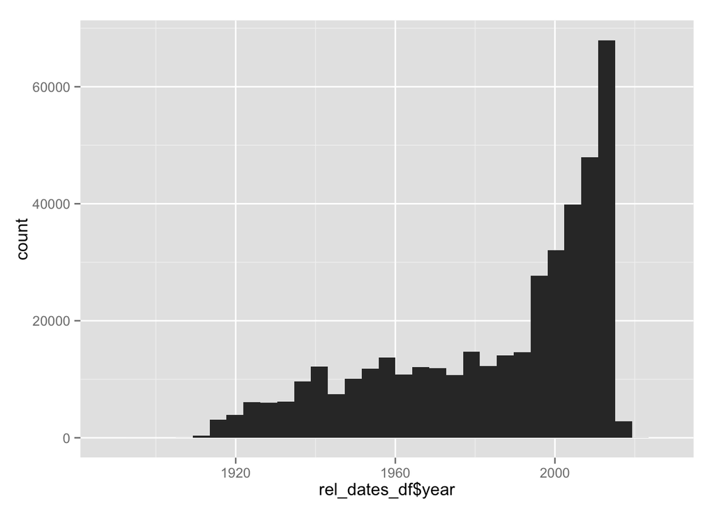

```r
library(ggplot2)
qplot(rel_dates_df$year)
```

*Note : Don’t start with qplot. You will not be able to learn the grammer properly. Depends on your knowledge*

## Historgram

### Bar Graph

#### Plot the number of films that have been released each decade over the history of cinema.

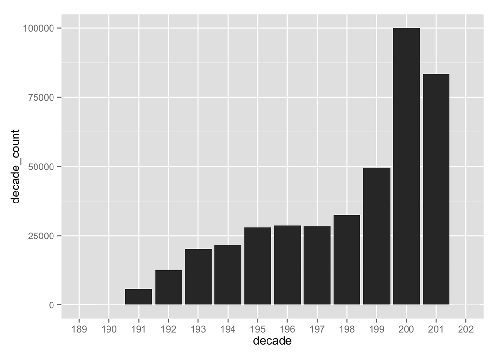

```r
library(ggplot2)
rel_dates_df %>%
  mutate(decade = as.factor(year %/% 10)) %>% # I havd to look at stackoverflow for remainder :P
  group_by(decade) %>%
  summarise(decade_count = n()) %>%
  ggplot(aes(x=decade, y= decade_count)) +
    geom_bar(stat="identity")
```

### Line Graph

#### How do India and USA rank based on number of releases over years?

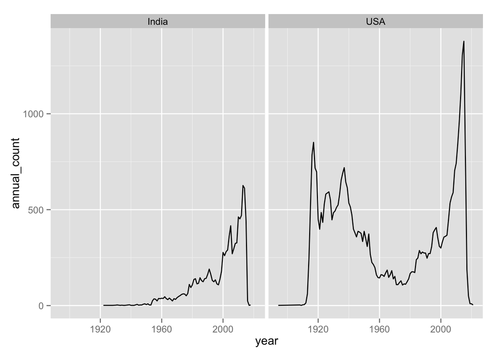

```r
rel_dates_df %>%
  filter(tolower(country)=='india' | tolower(country)=='usa')  %>%
  mutate(country = as.factor(country)) %>%
  group_by(country, year) %>%
  summarise(annual_count = n()) %>%
  ggplot(aes(x = year, y = annual_count)) +
    geom_line(stat="identity") +
    facet_wrap(~country)
```

### Scatter Plot

#### Plot the n-values of the roles that Scarlett Johansson has played over her career.

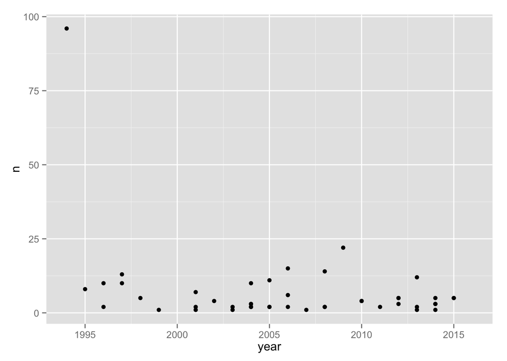

```r
cast_df %>%
  filter(name=="Scarlett Johansson") %>%
  ggplot(aes(x=year, y=n)) +
  geom_point()
```